# Prosper Loan Exploration

## by Favour Anazodo

- Introduction
- Data Gathering
- Assessing the Data
- Cleaning Data
- Exploratory Data Analysis
- Univariate
- Bivariate
- Multivariate
- Conclusion

## Introduction

[Prosper Marketplace Inc](https://en.wikipedia.org/wiki/Prosper_Marketplace), is a San Francisco, California based company in the peer-to-peer lending industry. Prosper Funding LLC, one of its subsidiaries, operates [Prosper.com](https://www.prosper.com/), a website where individuals can either invest in personal loans or request to borrow money.

Analysis on this dataset would answer some questions like which state requests for alot or which state request for large amount of loan? why do people request for loan? what profession requests for loan regularly? what loan amount is the most common? looking at the borrower's interest rate with respect to the loan amount and the annual income of the borrower, how does a good rating help a borrower? looking at the estimated loss, return and effective yield wih respect to prosper rating, what makes a good prosper rating?

The dataset which was provided as a support material by Udacity contains 113,937 loans with 81 variables and definition of the variables in the dataset is given below.

### **Data Dictionary**

- **ListingKey**:- Unique key for each listing, same value as the 'key' used in the listing object in the API.
- **ListingNumber**:- The number that uniquely identifies the listing to the public as displayed on the website.
- **ListingCreationDate**:- The date the listing was created.
- **CreditGrade**:- The Credit rating that was assigned at the time the listing went live. Applicable for listings pre-2009 period and will only be populated for those listings.
- **Term**:- The length of the loan expressed in months.
- **LoanStatus**:- The current status of the loan: Cancelled, Chargedoff, Completed, Current, Defaulted, FinalPaymentInProgress, PastDue. The PastDue status will be accompanied by a delinquency bucket.
- **ClosedDate**:- Closed date is applicable for Cancelled, Completed, Chargedoff and Defaulted loan statuses.
- **BorrowerAPR**:- The Borrower's Annual Percentage Rate (APR) for the loan.
- **BorrowerRate**:- The Borrower's interest rate for this loan.
- **LenderYield**:- The Lender yield on the loan. Lender yield is equal to the interest rate on the loan less the servicing fee.
- **EstimatedEffectiveYield**:-Effective yield is equal to the borrower interest rate (i) minus the servicing fee rate, (ii) minus| estimated uncollected interest on charge-offs, (iii) plus estimated collected late fees. Applicable for loans originated after July 2009.
- **EstimatedLoss**:- Estimated loss is the estimated principal loss on charge-offs. Applicable for loans originated after July 2009.
- **EstimatedReturn**:- The estimated return assigned to the listing at the time it was created. Estimated return is the difference between the Estimated Effective Yield and the Estimated Loss Rate. Applicable for loans originated after July 2009.
- **ProsperRating(numeric)**:- The Prosper Rating assigned at the time the listing was created: 0 - N/A, 1 - HR, 2 - E, 3 - D, 4 - C, 5 - B, 6 - A, 7 - AA. Applicable for loans originated after July 2009.
- **ProsperRating(Alpha)**:- The Prosper Rating assigned at the time the listing was created between AA - HR. Applicable for loans originated after July 2009.
- **ProsperScore**:- A custom risk score built using historical Prosper data. The score ranges from 1-10, with 10 being the best, or lowest risk score. Applicable for loans originated after July 2009.
- **ListingCategory**:- The category of the listing that the borrower selected when posting their listing: 0 - Not Available, 1 - Debt Consolidation, 2 - Home Improvement, 3 - Business, 4 - Personal Loan, 5 - Student Use, 6 - Auto, 7- Other, 8 - Baby&Adoption, 9 - Boat, 10 - Cosmetic Procedure, 11 - Engagement Ring, 12 - Green Loans, 13 - Household Expenses, 14 - Large Purchases, 15 - Medical/Dental, 16 - Motorcycle, 17 - RV, 18 - Taxes, 19 - Vacation, 20 - Wedding Loans
- **BorrowerState**:- The two letter abbreviation of the state of the address of the borrower at the time the Listing was created.
- **Occupation**:- The Occupation selected by the Borrower at the time they created the listing.
- **EmploymentStatus**:- The employment status of the borrower at the time they posted the listing.
- **EmploymentStatusDuration**:- The length in months of the employment status at the time the listing was created.
- **IsBorrowerHomeowner**:- A Borrower will be classified as a homowner if they have a mortgage on their credit profile or provide documentation confirming they are a homeowner.
- **CurrentlyInGroup**:- Specifies whether or not the Borrower was in a group at the time the listing was created.
- **GroupKey**:- The Key of the group in which the Borrower is a member of. Value will be null if the borrower does not have a group affiliation.
- **DateCreditPulled**:- The date the credit profile was pulled.
- **CreditScoreRangeLower**:- The lower value representing the range of the borrower's credit score as provided by a consumer credit rating agency.
- **CreditScoreRangeUpper**:- The upper value representing the range of the borrower's credit score as provided by a consumer credit rating agency.
- **FirstRecordedCreditLine**:- The date the first credit line was opened.
- **CurrentCreditLines**:- Number of current credit lines at the time the credit profile was pulled.
- **OpenCreditLines**:- Number of open credit lines at the time the credit profile was pulled.
- **TotalCreditLinespast7years**:- Number of credit lines in the past seven years at the time the credit profile was pulled.
- **OpenRevolvingAccounts**:- Number of open revolving accounts at the time the credit profile was pulled.
- **OpenRevolvingMonthlyPayment**:- Monthly payment on revolving accounts at the time the credit profile was pulled.
- **InquiriesLast6Months**:- Number of inquiries in the past six months at the time the credit profile was pulled.
- **TotalInquiries**:- Total number of inquiries at the time the credit profile was pulled.
- **CurrentDelinquencies**:- Number of accounts delinquent at the time the credit profile was pulled.
- **AmountDelinquent**:- Dollars delinquent at the time the credit profile was pulled.
- **DelinquenciesLast7Years**:- Number of delinquencies in the past 7 years at the time the credit profile was pulled.
- **PublicRecordsLast10Years**:- Number of public records in the past 10 years at the time the credit profile was pulled.
- **PublicRecordsLast12Months**:- Number of public records in the past 12 months at the time the credit profile was pulled.
- **RevolvingCreditBalance**:- Dollars of revolving credit at the time the credit profile was pulled.
- **BankcardUtilization**:- The percentage of available revolving credit that is utilized at the time the credit profile was pulled.
- **AvailableBankcardCredit**:- The total available credit via bank card at the time the credit profile was pulled.
- **TotalTrades**:- Number of trade lines ever opened at the time the credit profile was pulled.
- **TradesNeverDelinquent**:- Number of trades that have never been delinquent at the time the credit profile was pulled.
- **TradesOpenedLast6Months**:- Number of trades opened in the last 6 months at the time the credit profile was pulled.
- **DebtToIncomeRatio**:- The debt to income ratio of the borrower at the time the credit profile was pulled. This value is Null if the debt to income ratio is not available. This value is capped at 10.01 (any debt to income ratio larger than 1000% will be returned as 1001%).
- **IncomeRange**:- The income range of the borrower at the time the listing was created.
- **IncomeVerifiable**:- The borrower indicated they have the required documentation to support their income.
- **StatedMonthlyIncome**:- The monthly income the borrower stated at the time the listing was created.
- **LoanKey**:- Unique key for each loan. This is the same key that is used in the API.
- **TotalProsperLoans**:- Number of Prosper loans the borrower at the time they created this listing. This value will be null if the borrower had no prior loans.
- **TotalProsperPaymentsBilled**:- Number of on time payments the borrower made on Prosper loans at the time they created this listing. This value will be null if the borrower had no prior loans.
- **OnTimeProsperPayments**:- Number of on time payments the borrower had made on Prosper loans at the time they created this listing. This value will be null if the borrower has no prior loans.
- **ProsperPaymentsLessThanOneMonthLate**:- Number of payments the borrower made on Prosper loans that were less than one month late at the time they created this listing. This value will be null if the borrower had no prior loans.
- **ProsperPaymentsOneMonthPlusLate**:- Number of payments the borrower made on Prosper loans that were greater than one month late at the time they created this listing. This value will be null if the borrower had no prior loans.
- **ProsperPrincipalBorrowed**:- Total principal borrowed on Prosper loans at the time the listing was created. This value will be null if the borrower had no prior loans.
- **ProsperPrincipalOutstanding**:- Principal outstanding on Prosper loans at the time the listing was created. This value will be null if the borrower had no prior loans.
- **ScorexChangeAtTimeOfListing**:- Borrower's credit score change at the time the credit profile was pulled. This will be the change relative to the borrower's last Prosper loan. This value will be null if the borrower had no prior loans.
- **LoanCurrentDaysDelinquent**:- The number of days delinquent.
- **LoanFirstDefaultedCycleNumber**:- The cycle the loan was charged off. If the loan has not charged off the value will be null.
- **LoanMonthsSinceOrigination**:- Number of months since the loan originated.
- **LoanNumber**:- Unique numeric value associated with the loan.
- **LoanOriginalAmount**:- The origination amount of the loan.
- **LoanOriginationDate**:- The date the loan was originated.
- **LoanOriginationQuarter**:- The quarter in which the loan was originated.
- **MemberKey**:- The unique key that is associated with the borrower. This is the same identifier that is used in the API member object.
- **MonthlyLoanPayment**:- The scheduled monthly loan payment.
- **LP_CustomerPayments**:- Pre charge-off cumulative gross payments made by the borrower on the loan. If the loan has charged off, this value will exclude any recoveries.
- **LP_CustomerPrincipalPayments**:- Pre charge-off cumulative principal payments made by the borrower on the loan. If the loan has charged off, this value will exclude any recoveries.
- **LP_InterestandFees**:- Pre charge-off cumulative interest and fees paid by the borrower. If the loan has charged off, this value will exclude any recoveries.
- **LP_ServiceFees**:- Cumulative service fees paid by the investors who have invested in the loan.
- **LP_CollectionFees**:- Cumulative collection fees paid by the investors who have invested in the loan.
- **LP_GrossPrincipalLoss**:- The gross charged off amount of the loan.
- **LP_NetPrincipalLoss**:- The principal that remains uncollected after any recoveries.
- **LP_NonPrincipalRecoverypayments**:- The interest and fee component of any recovery payments. The current payment policy applies payments in the following order: Fees, interest, principal.
- **PercentFunded** :- Percent the listing was funded.
- **Recommendations**:- Number of recommendations the borrower had at the time the listing was created.
- **InvestmentFromFriendsCount**:- Number of friends that made an investment in the loan.
- **InvestmentFromFriendsAmount**:- Dollar amount of investments that were made by friends.
- **Investors**:- The number of investors that funded the loan.

**NOTE**: *To get Prosper Data, you could request for their API.*

## Data Gathering

As stated above, dataset was downloaded as a csv file from Udacity supporting materials. What will be required will be to read the csv file using pandas and we get down to business!

```python
#Import necessary packages and set plot to be embedded inline
import pandas as pd
import numpy as np
import matplotlib.pyplot as plt
import seaborn as sns
%matplotlib inline
```

```python
#Read csv with pandas
prosper_loan_df = pd.read_csv('prosperLoanData.csv')
```

```python
prosper_loan_df.info()
```

```
<class 'pandas.core.frame.DataFrame'>
RangeIndex: 113937 entries, 0 to 113936
Data columns (total 81 columns):
 #   Column                               Non-Null Count   Dtype
---  ------                               --------------   -----
 0   ListingKey                           113937 non-null  object
 1   ListingNumber                        113937 non-null  int64
 2   ListingCreationDate                  113937 non-null  object
 3   CreditGrade                          28953 non-null   object
 4   Term                                 113937 non-null  int64
 5   LoanStatus                           113937 non-null  object
 6   ClosedDate                           55089 non-null   object
 7   BorrowerAPR                          113912 non-null  float64
 8   BorrowerRate                         113937 non-null  float64
 9   LenderYield                          113937 non-null  float64
```

[output cut: 73 more lines]

# Preliminary Wrangling

## Assessing Data

Good and proper analysis will require that gathered data is assessed for tidiness and quality issues so informations or facts gotten from data is accurate enough to make informed decisions.

For this analysis, I will not be making use of all 81 columns (that is a lot of columns!). I will be selecting columns that are necessary for my analysis which will contain 38 columns and 113937 rows instead.

```python
prosper_df = prosper_loan_df[['ListingKey','ListingCreationDate','ListingCategory (numeric)','BorrowerState','Occupation',
                                    'IsBorrowerHomeowner','EmploymentStatus','EmploymentStatusDuration','StatedMonthlyIncome',
                                    'IncomeRange','IncomeVerifiable','DebtToIncomeRatio','DateCreditPulled','CreditScoreRangeLower','CreditScoreRangeUpper',
                                    'ProsperScore','ProsperRating (numeric)','ProsperRating (Alpha)','CurrentDelinquencies',
                                    'AmountDelinquent','CurrentCreditLines','OpenCreditLines','OpenRevolvingMonthlyPayment','RevolvingCreditBalance',
                              'LoanOriginationDate','LoanOriginalAmount','Term','MonthlyLoanPayment','BorrowerRate',
                                'BorrowerAPR','EstimatedEffectiveYield','EstimatedLoss','EstimatedReturn','LenderYield',
                                'Recommendations','Investors','LoanStatus','ClosedDate']].copy()
```

```python
prosper_df
```

|  | ListingKey | ListingCreationDate | ListingCategory (numeric) | BorrowerState | Occupation | IsBorrowerHomeowner | EmploymentStatus | EmploymentStatusDuration | StatedMonthlyIncome | IncomeRange | ... | BorrowerRate | BorrowerAPR | EstimatedEffectiveYield | EstimatedLoss | EstimatedReturn | LenderYield | Recommendations | Investors | LoanStatus | ClosedDate |
| --- | --- | --- | --- | --- | --- | --- | --- | --- | --- | --- | --- | --- | --- | --- | --- | --- | --- | --- | --- | --- | --- |
| 0 | 1021339766868145413AB3B | 2007-08-26 19:09:29.263000000 | 0 | CO | Other | True | Self-employed | 2.0 | 3083.333333 | $25,000-49,999 | ... | 0.1580 | 0.16516 | NaN | NaN | NaN | 0.1380 | 0 | 258 | Completed | 2009-08-14 00:00:00 |
| 1 | 10273602499503308B223C1 | 2014-02-27 08:28:07.900000000 | 2 | CO | Professional | False | Employed | 44.0 | 6125.000000 | $50,000-74,999 | ... | 0.0920 | 0.12016 | 0.07960 | 0.0249 | 0.05470 | 0.0820 | 0 | 1 | Current | NaN |
| 2 | 0EE9337825851032864889A | 2007-01-05 15:00:47.090000000 | 0 | GA | Other | False | Not available | NaN | 2083.333333 | Not displayed | ... | 0.2750 | 0.28269 | NaN | NaN | NaN | 0.2400 | 0 | 41 | Completed | 2009-12-17 00:00:00 |
| 3 | 0EF5356002482715299901A | 2012-10-22 11:02:35.010000000 | 16 | GA | Skilled Labor | True | Employed | 113.0 | 2875.000000 | $25,000-49,999 | ... | 0.0974 | 0.12528 | 0.08490 | 0.0249 | 0.06000 | 0.0874 | 0 | 158 | Current | NaN |
| 4 | 0F023589499656230C5E3E2 | 2013-09-14 18:38:39.097000000 | 2 | MN | Executive | True | Employed | 44.0 | 9583.333333 | $100,000+ | ... | 0.2085 | 0.24614 | 0.18316 | 0.0925 | 0.09066 | 0.1985 | 0 | 20 | Current | NaN |
| ... | ... | ... | ... | ... | ... | ... | ... | ... | ... | ... | ... | ... | ... | ... | ... | ... | ... | ... | ... | ... | ... |
| 113932 | E6D9357655724827169606C | 2013-04-14 05:55:02.663000000 | 1 | IL | Food Service Management | True | Employed | 246.0 | 4333.333333 | $50,000-74,999 | ... | 0.1864 | 0.22354 | 0.16490 | 0.0699 | 0.09500 | 0.1764 | 0 | 1 | Current | NaN |
| 113933 | E6DB353036033497292EE43 | 2011-11-03 20:42:55.333000000 | 7 | PA | Professional | True | Employed | 21.0 | 8041.666667 | $75,000-99,999 | ... | 0.1110 | 0.13220 | 0.10070 | 0.0200 | 0.08070 | 0.1010 | 0 | 22 | FinalPaymentInProgress | NaN |
| 113934 | E6E13596170052029692BB1 | 2013-12-13 05:49:12.703000000 | 1 | TX | Other | True | Employed | 84.0 | 2875.000000 | $25,000-49,999 | ... | 0.2150 | 0.23984 | 0.18828 | 0.1025 | 0.08578 | 0.2050 | 0 | 119 | Current | NaN |
| 113935 | E6EB3531504622671970D9E | 2011-11-14 13:18:26.597000000 | 2 | GA | Food Service | True | Full-time | 94.0 | 3875.000000 | $25,000-49,999 | ... | 0.2605 | 0.28408 | 0.24450 | 0.0850 | 0.15950 | 0.2505 | 0 | 274 | Completed | 2013-08-13 00:00:00 |
| 113936 | E6ED3600409833199F711B7 | 2014-01-15 09:27:37.657000000 | 1 | NY | Professor | False | Employed | 244.0 | 4583.333333 | $50,000-74,999 | ... | 0.1039 | 0.13189 | 0.09071 | 0.0299 | 0.06081 | 0.0939 | 0 | 1 | Current | NaN |

113937 rows × 38 columns

```python
prosper_df.info()
```

```
<class 'pandas.core.frame.DataFrame'>
RangeIndex: 113937 entries, 0 to 113936
Data columns (total 38 columns):
 #   Column                       Non-Null Count   Dtype
---  ------                       --------------   -----
 0   ListingKey                   113937 non-null  object
 1   ListingCreationDate          113937 non-null  object
 2   ListingCategory (numeric)    113937 non-null  int64
 3   BorrowerState                108422 non-null  object
 4   Occupation                   110349 non-null  object
 5   IsBorrowerHomeowner          113937 non-null  bool
 6   EmploymentStatus             111682 non-null  object
 7   EmploymentStatusDuration     106312 non-null  float64
 8   StatedMonthlyIncome          113937 non-null  float64
 9   IncomeRange                  113937 non-null  object
```

[output cut: 30 more lines]

```python
# Check null values
prosper_df.isnull().sum()
```

```
ListingKey                         0
ListingCreationDate                0
ListingCategory (numeric)          0
BorrowerState                   5515
Occupation                      3588
IsBorrowerHomeowner                0
EmploymentStatus                2255
EmploymentStatusDuration        7625
StatedMonthlyIncome                0
IncomeRange                        0
IncomeVerifiable                   0
DebtToIncomeRatio               8554
DateCreditPulled                   0
CreditScoreRangeLower            591
CreditScoreRangeUpper            591
ProsperScore                   29084
ProsperRating (numeric)        29084
ProsperRating (Alpha)          29084
CurrentDelinquencies             697
AmountDelinquent                7622
CurrentCreditLines              7604
OpenCreditLines                 7604
OpenRevolvingMonthlyPayment        0
RevolvingCreditBalance          7604
LoanOriginationDate                0
LoanOriginalAmount                 0
Term                               0
MonthlyLoanPayment                 0
BorrowerRate                       0
BorrowerAPR                       25
EstimatedEffectiveYield        29084
EstimatedLoss                  29084
EstimatedReturn                29084
LenderYield                        0
Recommendations                    0
Investors                          0
LoanStatus                         0
ClosedDate                     58848
dtype: int64
```

```python
# Check duplicates
prosper_df.duplicated().sum()
```

```
0
```

It should be noted that this ListingKey cannot be the same for any Borrower.

```python
# Check duplicates on ListingKey
prosper_df['ListingKey'].duplicated().sum()
```

```
871
```

```python
prosper_df['ListingKey'].value_counts()
```

```
17A93590655669644DB4C06    6
DE8535960513435199406CE    4
47C1359638497431975670B    4
8474358854651984137201C    4
349D3587495831350F0F648    4
                          ..
5F873598134737792133EFB    1
7CC335488206169765B8986    1
D00E35768849761755733E8    1
67E03590130327200443066    1
5D4535892725863740A1B7D    1
Name: ListingKey, Length: 113066, dtype: int64
```

```python
# Run query with a ListingKey showing multiple value counts
prosper_df.query('ListingKey=="17A93590655669644DB4C06"')
```

|  | ListingKey | ListingCreationDate | ListingCategory (numeric) | BorrowerState | Occupation | IsBorrowerHomeowner | EmploymentStatus | EmploymentStatusDuration | StatedMonthlyIncome | IncomeRange | ... | BorrowerRate | BorrowerAPR | EstimatedEffectiveYield | EstimatedLoss | EstimatedReturn | LenderYield | Recommendations | Investors | LoanStatus | ClosedDate |
| --- | --- | --- | --- | --- | --- | --- | --- | --- | --- | --- | --- | --- | --- | --- | --- | --- | --- | --- | --- | --- | --- |
| 13078 | 17A93590655669644DB4C06 | 2013-10-02 17:20:16.550000000 | 1 | MD | Other | False | Employed | 26.0 | 3000.0 | $25,000-49,999 | ... | 0.1435 | 0.16662 | 0.1264 | 0.0524 | 0.074 | 0.1335 | 0 | 96 | Current | NaN |
| 14888 | 17A93590655669644DB4C06 | 2013-10-02 17:20:16.550000000 | 1 | MD | Other | False | Employed | 26.0 | 3000.0 | $25,000-49,999 | ... | 0.1435 | 0.16662 | 0.1264 | 0.0524 | 0.074 | 0.1335 | 0 | 96 | Current | NaN |
| 20569 | 17A93590655669644DB4C06 | 2013-10-02 17:20:16.550000000 | 1 | MD | Other | False | Employed | 26.0 | 3000.0 | $25,000-49,999 | ... | 0.1435 | 0.16662 | 0.1264 | 0.0524 | 0.074 | 0.1335 | 0 | 96 | Current | NaN |
| 31450 | 17A93590655669644DB4C06 | 2013-10-02 17:20:16.550000000 | 1 | MD | Other | False | Employed | 26.0 | 3000.0 | $25,000-49,999 | ... | 0.1435 | 0.16662 | 0.1264 | 0.0524 | 0.074 | 0.1335 | 0 | 96 | Current | NaN |
| 42750 | 17A93590655669644DB4C06 | 2013-10-02 17:20:16.550000000 | 1 | MD | Other | False | Employed | 26.0 | 3000.0 | $25,000-49,999 | ... | 0.1435 | 0.16662 | 0.1264 | 0.0524 | 0.074 | 0.1335 | 0 | 96 | Current | NaN |
| 42751 | 17A93590655669644DB4C06 | 2013-10-02 17:20:16.550000000 | 1 | MD | Other | False | Employed | 26.0 | 3000.0 | $25,000-49,999 | ... | 0.1435 | 0.16662 | 0.1264 | 0.0524 | 0.074 | 0.1335 | 0 | 96 | Current | NaN |

6 rows × 38 columns

#### Quality Issues

- Null values
- Datatypes of ListingCreationDate, DateCreditPulled
- Duplicates in dataset

#### Tidiness issues

- Listing category column in numeric

## Data Cleaning

**Define**

Deal with null values using dropna and fillna

**Code**

```python
# drop rows with null values in the ProsperRating (Alpha) column
prosper_df = prosper_df.dropna(subset=['ProsperRating (Alpha)']).copy()
```

**Test**

```python
prosper_df.info()
```

```
<class 'pandas.core.frame.DataFrame'>
Int64Index: 84853 entries, 1 to 113936
Data columns (total 38 columns):
 #   Column                       Non-Null Count  Dtype
---  ------                       --------------  -----
 0   ListingKey                   84853 non-null  object
 1   ListingCreationDate          84853 non-null  object
 2   ListingCategory (numeric)    84853 non-null  int64
 3   BorrowerState                84853 non-null  object
 4   Occupation                   83520 non-null  object
 5   IsBorrowerHomeowner          84853 non-null  bool
 6   EmploymentStatus             84853 non-null  object
 7   EmploymentStatusDuration     84834 non-null  float64
 8   StatedMonthlyIncome          84853 non-null  float64
 9   IncomeRange                  84853 non-null  object
```

[output cut: 30 more lines]

**Code**

There are still some null values, using fillna to work on null values

```python
# Fill null values with 0
prosper_df.fillna(0,inplace=True)
```

**Test**

```python
prosper_df.isnull().sum()
```

```
ListingKey                     0
ListingCreationDate            0
ListingCategory (numeric)      0
BorrowerState                  0
Occupation                     0
IsBorrowerHomeowner            0
EmploymentStatus               0
EmploymentStatusDuration       0
StatedMonthlyIncome            0
IncomeRange                    0
IncomeVerifiable               0
DebtToIncomeRatio              0
DateCreditPulled               0
CreditScoreRangeLower          0
CreditScoreRangeUpper          0
ProsperScore                   0
ProsperRating (numeric)        0
ProsperRating (Alpha)          0
CurrentDelinquencies           0
AmountDelinquent               0
CurrentCreditLines             0
OpenCreditLines                0
OpenRevolvingMonthlyPayment    0
RevolvingCreditBalance         0
LoanOriginationDate            0
LoanOriginalAmount             0
Term                           0
MonthlyLoanPayment             0
BorrowerRate                   0
BorrowerAPR                    0
EstimatedEffectiveYield        0
EstimatedLoss                  0
EstimatedReturn                0
LenderYield                    0
Recommendations                0
Investors                      0
LoanStatus                     0
ClosedDate                     0
dtype: int64
```

```python
prosper_df.info()
```

```
<class 'pandas.core.frame.DataFrame'>
Int64Index: 84853 entries, 1 to 113936
Data columns (total 38 columns):
 #   Column                       Non-Null Count  Dtype
---  ------                       --------------  -----
 0   ListingKey                   84853 non-null  object
 1   ListingCreationDate          84853 non-null  object
 2   ListingCategory (numeric)    84853 non-null  int64
 3   BorrowerState                84853 non-null  object
 4   Occupation                   84853 non-null  object
 5   IsBorrowerHomeowner          84853 non-null  bool
 6   EmploymentStatus             84853 non-null  object
 7   EmploymentStatusDuration     84853 non-null  float64
 8   StatedMonthlyIncome          84853 non-null  float64
 9   IncomeRange                  84853 non-null  object
```

[output cut: 30 more lines]

**Define**

Drop ListingKey that are duplicated but keep the first row

**Code**

```python
prosper_df.drop_duplicates(['ListingKey'], keep='first', inplace=True)
```

**Test**

```python
prosper_df['ListingKey'].duplicated().sum()
```

```
0
```

```python
prosper_df.query('ListingKey=="17A93590655669644DB4C06"')
```

|  | ListingKey | ListingCreationDate | ListingCategory (numeric) | BorrowerState | Occupation | IsBorrowerHomeowner | EmploymentStatus | EmploymentStatusDuration | StatedMonthlyIncome | IncomeRange | ... | BorrowerRate | BorrowerAPR | EstimatedEffectiveYield | EstimatedLoss | EstimatedReturn | LenderYield | Recommendations | Investors | LoanStatus | ClosedDate |
| --- | --- | --- | --- | --- | --- | --- | --- | --- | --- | --- | --- | --- | --- | --- | --- | --- | --- | --- | --- | --- | --- |
| 13078 | 17A93590655669644DB4C06 | 2013-10-02 17:20:16.550000000 | 1 | MD | Other | False | Employed | 26.0 | 3000.0 | $25,000-49,999 | ... | 0.1435 | 0.16662 | 0.1264 | 0.0524 | 0.074 | 0.1335 | 0 | 96 | Current | 0 |

1 rows × 38 columns

**Define**

**Note**: Though 2 of the ListingCreationDate show it appears twice it does not mean it is duplicated.

**Code**

```python
prosper_df['ListingCreationDate'].value_counts()
```

```
2013-06-03 17:27:50.540000000    2
2012-10-20 12:21:46.333000000    2
2013-10-05 02:22:00.653000000    1
2014-02-20 10:24:25.443000000    1
2011-08-25 00:26:28.320000000    1
                                ..
2013-12-02 10:02:49.647000000    1
2013-11-11 07:48:53.477000000    1
2013-04-11 11:29:25.210000000    1
2013-06-10 21:59:38.743000000    1
2011-11-22 06:33:40.730000000    1
Name: ListingCreationDate, Length: 83980, dtype: int64
```

```python
prosper_df.query('ListingCreationDate == "2012-10-20 12:21:46.333000000"')
```

|  | ListingKey | ListingCreationDate | ListingCategory (numeric) | BorrowerState | Occupation | IsBorrowerHomeowner | EmploymentStatus | EmploymentStatusDuration | StatedMonthlyIncome | IncomeRange | ... | BorrowerRate | BorrowerAPR | EstimatedEffectiveYield | EstimatedLoss | EstimatedReturn | LenderYield | Recommendations | Investors | LoanStatus | ClosedDate |
| --- | --- | --- | --- | --- | --- | --- | --- | --- | --- | --- | --- | --- | --- | --- | --- | --- | --- | --- | --- | --- | --- |
| 4492 | 06C83560167948313B40358 | 2012-10-20 12:21:46.333000000 | 1 | CA | Professional | False | Employed | 104.0 | 7500.000000 | $75,000-99,999 | ... | 0.1599 | 0.19645 | 0.1417 | 0.0549 | 0.0868 | 0.1499 | 0 | 220 | Completed | 2013-10-30 00:00:00 |
| 51506 | ECB43560655055911B1C28E | 2012-10-20 12:21:46.333000000 | 1 | IL | Social Worker | False | Employed | 15.0 | 4333.333333 | $50,000-74,999 | ... | 0.3177 | 0.35797 | 0.2799 | 0.1625 | 0.1174 | 0.3077 | 0 | 51 | Current | 0 |

2 rows × 38 columns

```python
# Create datatype converter function
def datatype_converter(df, col_name, datatype):
    df[col_name] = df[col_name].astype(datatype)
    return (df[col_name])
```

```python
# Convert
datatype_converter(prosper_df,'ListingCreationDate','datetime64[ns]')
datatype_converter(prosper_df,'DateCreditPulled','datetime64[ns]')
datatype_converter(prosper_df,'LoanOriginationDate','datetime64[ns]')
datatype_converter(prosper_df,'ClosedDate','datetime64[ns]')
```

```
1        1970-01-01
3        1970-01-01
4        1970-01-01
5        1970-01-01
6        1970-01-01
            ...
113932   1970-01-01
113933   1970-01-01
113934   1970-01-01
113935   2013-08-13
113936   1970-01-01
Name: ClosedDate, Length: 83982, dtype: datetime64[ns]
```

**Test**

```python
prosper_df.info()
```

```
<class 'pandas.core.frame.DataFrame'>
Int64Index: 83982 entries, 1 to 113936
Data columns (total 38 columns):
 #   Column                       Non-Null Count  Dtype
---  ------                       --------------  -----
 0   ListingKey                   83982 non-null  object
 1   ListingCreationDate          83982 non-null  datetime64[ns]
 2   ListingCategory (numeric)    83982 non-null  int64
 3   BorrowerState                83982 non-null  object
 4   Occupation                   83982 non-null  object
 5   IsBorrowerHomeowner          83982 non-null  bool
 6   EmploymentStatus             83982 non-null  object
 7   EmploymentStatusDuration     83982 non-null  float64
 8   StatedMonthlyIncome          83982 non-null  float64
 9   IncomeRange                  83982 non-null  object
```

[output cut: 30 more lines]

**Define**

ListingCategory which has numeric values will be replaced with the actual meaning of the numbers as shown in the Data Dictionary above and rename the column title

**Code**

```python
# Map the lisitng category
category_map = {0:'Not available', 1:'Debt consolidation', 2:'Home improvement', 3:'Business', 4:'Personal loan',
                5:'Student use', 6:'Auto', 7:'Other', 8:'Baby & Adoption Loans', 9:'Boat', 10:'Cosmetic Procedures',
                11:'Engagement Ring Financing', 12:'Green Loans', 13:'Household Expenses', 14:'Large Purchases',
                15:'Medical/Dental', 16:'Motorcycle', 17:'RV', 18:'Taxes', 19:'Vacation', 20:'Wedding Loans'}
prosper_df['ListingCategory (numeric)'] = prosper_df['ListingCategory (numeric)'].map(category_map)
```

```python
# Rename column
prosper_df=prosper_df.rename(columns={'ListingCategory (numeric)':'ListingCategory'})
```

**Test**

```python
prosper_df.head(5)
```

|  | ListingKey | ListingCreationDate | ListingCategory | BorrowerState | Occupation | IsBorrowerHomeowner | EmploymentStatus | EmploymentStatusDuration | StatedMonthlyIncome | IncomeRange | ... | BorrowerRate | BorrowerAPR | EstimatedEffectiveYield | EstimatedLoss | EstimatedReturn | LenderYield | Recommendations | Investors | LoanStatus | ClosedDate |
| --- | --- | --- | --- | --- | --- | --- | --- | --- | --- | --- | --- | --- | --- | --- | --- | --- | --- | --- | --- | --- | --- |
| 1 | 10273602499503308B223C1 | 2014-02-27 08:28:07.900 | Home improvement | CO | Professional | False | Employed | 44.0 | 6125.000000 | $50,000-74,999 | ... | 0.0920 | 0.12016 | 0.07960 | 0.0249 | 0.05470 | 0.0820 | 0 | 1 | Current | 1970-01-01 |
| 3 | 0EF5356002482715299901A | 2012-10-22 11:02:35.010 | Motorcycle | GA | Skilled Labor | True | Employed | 113.0 | 2875.000000 | $25,000-49,999 | ... | 0.0974 | 0.12528 | 0.08490 | 0.0249 | 0.06000 | 0.0874 | 0 | 158 | Current | 1970-01-01 |
| 4 | 0F023589499656230C5E3E2 | 2013-09-14 18:38:39.097 | Home improvement | MN | Executive | True | Employed | 44.0 | 9583.333333 | $100,000+ | ... | 0.2085 | 0.24614 | 0.18316 | 0.0925 | 0.09066 | 0.1985 | 0 | 20 | Current | 1970-01-01 |
| 5 | 0F05359734824199381F61D | 2013-12-14 08:26:37.093 | Debt consolidation | NM | Professional | True | Employed | 82.0 | 8333.333333 | $100,000+ | ... | 0.1314 | 0.15425 | 0.11567 | 0.0449 | 0.07077 | 0.1214 | 0 | 1 | Current | 1970-01-01 |
| 6 | 0F0A3576754255009D63151 | 2013-04-12 09:52:56.147 | Debt consolidation | KS | Sales - Retail | False | Employed | 172.0 | 2083.333333 | $25,000-49,999 | ... | 0.2712 | 0.31032 | 0.23820 | 0.1275 | 0.11070 | 0.2612 | 0 | 1 | Current | 1970-01-01 |

5 rows × 38 columns

**Define**

Add extra column to calculate the Annual income using the StatedMonthlyIncome column

**Code**

```python
# Multiply monthly income by 12
prosper_df['AnnualIncome'] = prosper_df['StatedMonthlyIncome'] *12
```

Rearranging the columns

```python
prosper_df=prosper_df[['ListingKey','ListingCreationDate','ListingCategory','BorrowerState','Occupation',
                                    'IsBorrowerHomeowner','EmploymentStatus','EmploymentStatusDuration','StatedMonthlyIncome','AnnualIncome',
                                    'IncomeRange','IncomeVerifiable','DebtToIncomeRatio','DateCreditPulled','CreditScoreRangeLower','CreditScoreRangeUpper',
                                    'ProsperScore','ProsperRating (numeric)','ProsperRating (Alpha)','CurrentDelinquencies',
                                    'AmountDelinquent','CurrentCreditLines','OpenCreditLines','OpenRevolvingMonthlyPayment','RevolvingCreditBalance',
                              'LoanOriginationDate','LoanOriginalAmount','Term','MonthlyLoanPayment','BorrowerRate',
                                'BorrowerAPR','EstimatedEffectiveYield','EstimatedLoss','EstimatedReturn','LenderYield',
                                'Recommendations','Investors','LoanStatus','ClosedDate']]
```

**Test**

```python
prosper_df
```

|  | ListingKey | ListingCreationDate | ListingCategory | BorrowerState | Occupation | IsBorrowerHomeowner | EmploymentStatus | EmploymentStatusDuration | StatedMonthlyIncome | AnnualIncome | ... | BorrowerRate | BorrowerAPR | EstimatedEffectiveYield | EstimatedLoss | EstimatedReturn | LenderYield | Recommendations | Investors | LoanStatus | ClosedDate |
| --- | --- | --- | --- | --- | --- | --- | --- | --- | --- | --- | --- | --- | --- | --- | --- | --- | --- | --- | --- | --- | --- |
| 1 | 10273602499503308B223C1 | 2014-02-27 08:28:07.900 | Home improvement | CO | Professional | False | Employed | 44.0 | 6125.000000 | 73500.000000 | ... | 0.0920 | 0.12016 | 0.07960 | 0.0249 | 0.05470 | 0.0820 | 0 | 1 | Current | 1970-01-01 |
| 3 | 0EF5356002482715299901A | 2012-10-22 11:02:35.010 | Motorcycle | GA | Skilled Labor | True | Employed | 113.0 | 2875.000000 | 34500.000000 | ... | 0.0974 | 0.12528 | 0.08490 | 0.0249 | 0.06000 | 0.0874 | 0 | 158 | Current | 1970-01-01 |
| 4 | 0F023589499656230C5E3E2 | 2013-09-14 18:38:39.097 | Home improvement | MN | Executive | True | Employed | 44.0 | 9583.333333 | 114999.999996 | ... | 0.2085 | 0.24614 | 0.18316 | 0.0925 | 0.09066 | 0.1985 | 0 | 20 | Current | 1970-01-01 |
| 5 | 0F05359734824199381F61D | 2013-12-14 08:26:37.093 | Debt consolidation | NM | Professional | True | Employed | 82.0 | 8333.333333 | 99999.999996 | ... | 0.1314 | 0.15425 | 0.11567 | 0.0449 | 0.07077 | 0.1214 | 0 | 1 | Current | 1970-01-01 |
| 6 | 0F0A3576754255009D63151 | 2013-04-12 09:52:56.147 | Debt consolidation | KS | Sales - Retail | False | Employed | 172.0 | 2083.333333 | 24999.999996 | ... | 0.2712 | 0.31032 | 0.23820 | 0.1275 | 0.11070 | 0.2612 | 0 | 1 | Current | 1970-01-01 |
| ... | ... | ... | ... | ... | ... | ... | ... | ... | ... | ... | ... | ... | ... | ... | ... | ... | ... | ... | ... | ... | ... |
| 113932 | E6D9357655724827169606C | 2013-04-14 05:55:02.663 | Debt consolidation | IL | Food Service Management | True | Employed | 246.0 | 4333.333333 | 51999.999996 | ... | 0.1864 | 0.22354 | 0.16490 | 0.0699 | 0.09500 | 0.1764 | 0 | 1 | Current | 1970-01-01 |
| 113933 | E6DB353036033497292EE43 | 2011-11-03 20:42:55.333 | Other | PA | Professional | True | Employed | 21.0 | 8041.666667 | 96500.000004 | ... | 0.1110 | 0.13220 | 0.10070 | 0.0200 | 0.08070 | 0.1010 | 0 | 22 | FinalPaymentInProgress | 1970-01-01 |
| 113934 | E6E13596170052029692BB1 | 2013-12-13 05:49:12.703 | Debt consolidation | TX | Other | True | Employed | 84.0 | 2875.000000 | 34500.000000 | ... | 0.2150 | 0.23984 | 0.18828 | 0.1025 | 0.08578 | 0.2050 | 0 | 119 | Current | 1970-01-01 |
| 113935 | E6EB3531504622671970D9E | 2011-11-14 13:18:26.597 | Home improvement | GA | Food Service | True | Full-time | 94.0 | 3875.000000 | 46500.000000 | ... | 0.2605 | 0.28408 | 0.24450 | 0.0850 | 0.15950 | 0.2505 | 0 | 274 | Completed | 2013-08-13 |
| 113936 | E6ED3600409833199F711B7 | 2014-01-15 09:27:37.657 | Debt consolidation | NY | Professor | False | Employed | 244.0 | 4583.333333 | 54999.999996 | ... | 0.1039 | 0.13189 | 0.09071 | 0.0299 | 0.06081 | 0.0939 | 0 | 1 | Current | 1970-01-01 |

83982 rows × 39 columns

## Exploratory Data Analysis

As stated in the Introduction, we would love to answer questions such as

- why do people request for loan?
- what loan amount is the most common?
- which state requests for loan alot?
- which occupation requests for loan alot?
- will the unemployed also request for loans?
- does the annual income affect the APR?
- which state request for large amount of loan?
- what can we say really affects interest rate?
- how does a good rating help a borrower?
- interest rate and lender yield
- does smaller amount of loan mean the loan will be cleared faster?
- the monthly payment
- viewing interest rate with term
- looking at the estimated loss, return and effective yield wih respect to prosper rating
- state and income range

## Univariate

**Question**

### 1) Reason for requesting a loan?

Looking at the first question when you hear someone requests for a loan, which will be what is the loan for?

Using the ListingCategory variable

```python
#Making column as category type
category = ['Debt consolidation','Other','Home improvement','Business','Auto',
            'Household Expenses','Medical/Dental','Taxes','Large Purchases','Vacation','Wedding Loans','Motorcycle','Student use',
            'Engagement Ring Financing','Baby & Adoption Loans','Cosmetic Procedures','Boat','Green Loans','RV','Personal loan']
loan_cat = pd.api.types.CategoricalDtype(ordered=True, categories=category)
prosper_df['ListingCategory'] = prosper_df['ListingCategory'].astype(loan_cat)
```

**Visualization**

```python
prosper_df['ListingCategory'].value_counts()
```

```
Debt consolidation           52496
Other                         9172
Home improvement              6756
Business                      5266
Auto                          2233
Household Expenses            1987
Medical/Dental                1507
Taxes                          882
Large Purchases                863
Vacation                       764
Wedding Loans                  762
Motorcycle                     304
Student use                    274
Engagement Ring Financing      214
Baby & Adoption Loans          196
Cosmetic Procedures             91
Boat                            85
Green Loans                     58
RV                              52
Personal loan                    0
Name: ListingCategory, dtype: int64
```

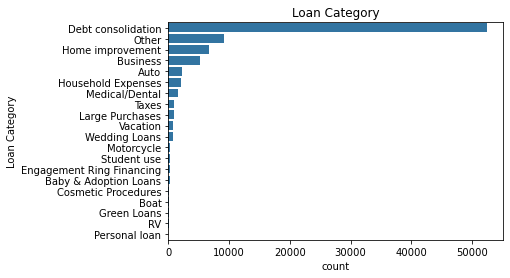

```python
# let's checkout all the categories
base_color=sns.color_palette()[0]
sns.countplot(data=prosper_df, y='ListingCategory', color=base_color)
plt.title('Loan Category')
plt.ylabel('Loan Category')
plt.show()
```

**Observation**

Most people request for loan for Debt consolidation that is taking a loan to pay off other debts, while the next is Other, I am guessing this is because the borrower did not specify what the loan is needed for or the option for why he/she needs a loan was in stated. After which is Home improvement and Business.

Other loan categories that are not very common are Personal loans, RV (Recreational Vehicle), Green Loans (for sustainable, environmentally friendly purposes), Boat and Cosmetic procedures.

```python
prosper_df.info()
```

```
<class 'pandas.core.frame.DataFrame'>
Int64Index: 83982 entries, 1 to 113936
Data columns (total 39 columns):
 #   Column                       Non-Null Count  Dtype
---  ------                       --------------  -----
 0   ListingKey                   83982 non-null  object
 1   ListingCreationDate          83982 non-null  datetime64[ns]
 2   ListingCategory              83962 non-null  category
 3   BorrowerState                83982 non-null  object
 4   Occupation                   83982 non-null  object
 5   IsBorrowerHomeowner          83982 non-null  bool
 6   EmploymentStatus             83982 non-null  object
 7   EmploymentStatusDuration     83982 non-null  float64
 8   StatedMonthlyIncome          83982 non-null  float64
 9   AnnualIncome                 83982 non-null  float64
```

[output cut: 31 more lines]

**Question**

### 2) Loan amount commonly requested for?

```python
prosper_df['LoanOriginalAmount'].describe()
```

```
count    83982.000000
mean      9061.224381
std       6279.649648
min       1000.000000
25%       4000.000000
50%       7500.000000
75%      13500.000000
max      35000.000000
Name: LoanOriginalAmount, dtype: float64
```

**Visualization 1**

```python
prosper_df['BorrowerRate'].describe()
```

```
count    83982.00000
mean         0.19630
std          0.07475
min          0.04000
25%          0.13590
50%          0.18750
75%          0.25740
max          0.36000
Name: BorrowerRate, dtype: float64
```

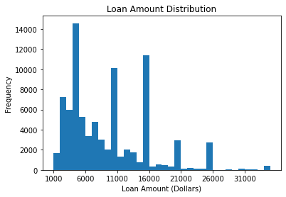

```python
# with a standard scaled plot
bins = np.arange(1000, prosper_df['LoanOriginalAmount'].max()+20, 1000)
plt.hist(data=prosper_df, x='LoanOriginalAmount', bins=bins)
plt.xlabel('Loan Amount (Dollars)')
plt.ylabel('Frequency')
plt.title('Loan Amount Distribution')
plt.xticks(np.arange(1000,35000+20,5000))
plt.show()
```

**Observation 1**

Plot shows a slight skew to the right loan amount is mostly around 1000 to 6000 and with a spike around 11000 and 16000

```python
# getting the log value
np.log10(prosper_df['LoanOriginalAmount']).describe()
```

```
count    83982.000000
mean         3.848422
std          0.320090
min          3.000000
25%          3.602060
50%          3.875061
75%          4.130334
max          4.544068
Name: LoanOriginalAmount, dtype: float64
```

**Visualization 2**

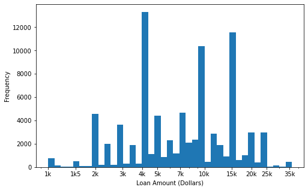

```python
# trying out a log scale
log_binsize = 0.04
bins = 10 ** np.arange(3, np.log10(prosper_df['LoanOriginalAmount'].max())+log_binsize, log_binsize)

plt.figure(figsize=[8, 5])
plt.hist(data = prosper_df, x = 'LoanOriginalAmount', bins = bins)
plt.xscale('log')
plt.xticks([1e3,1.5e3, 2e3, 3e3, 4e3, 5e3, 7e3, 1e4, 1.5e4, 2e4,2.5e4, 3.5e4], ['1k','1k5', '2k', '3k', '4k','5k','7k','10k', '15k','20k','25k','35k'])
plt.xlabel('Loan Amount (Dollars)')
plt.ylabel('Frequency')
plt.show()
```

**Observation 2**

**Question**

### 3) Which state is known for loan requests

```python
# Replace 0 with N/A
bor_state=prosper_df['BorrowerState'].value_counts().rename_axis('state').reset_index(name='count').replace(0,'N/A')
bor_state.info()
```

```
<class 'pandas.core.frame.DataFrame'>
RangeIndex: 48 entries, 0 to 47
Data columns (total 2 columns):
 #   Column  Non-Null Count  Dtype
---  ------  --------------  -----
 0   state   48 non-null     object
 1   count   48 non-null     int64
dtypes: int64(1), object(1)
memory usage: 896.0+ bytes
```

```python
# Divide data into sections to avoid overplotting
state1 = bor_state.iloc[:12]
state2 = bor_state.iloc[12:24]
state3 = bor_state.iloc[24:36]
state4 = bor_state.iloc[36:]
```

**Visualization**

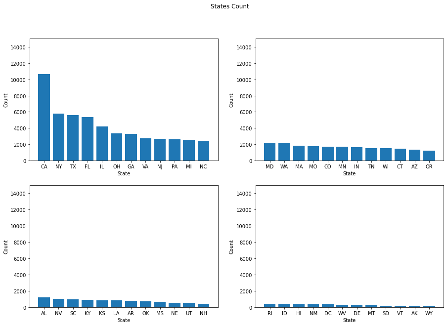

```python
# Plot with bar graph
plt.figure(figsize=[15,10])

# subplot 1
plt.subplot(2,2,1)
plt.bar(data=state1, x='state', height='count')
plt.ylim(0,15000)
plt.xlabel('State')
plt.ylabel('Count')

#subplot 2
plt.subplot(2,2,2)
plt.bar(data=state2, x='state', height='count')
plt.ylim(0,15000)
plt.xlabel('State')
plt.ylabel('Count')

# subplot 3
plt.subplot(2,2,3)
plt.bar(data=state3, x='state', height='count')
plt.ylim(0,15000)
plt.xlabel('State')
plt.ylabel('Count')

# subplot 4
plt.subplot(2,2,4)
plt.bar(data=state4, x='state', height='count')
plt.ylim(0,15000)
plt.xlabel('State')
plt.ylabel('Count')

plt.suptitle('States Count')
plt.show()
```

**Observation**

The top 5 states that request for loan alot is California(CA) followed by New York(NY), Texas(TX), Florida(FL) and Illinois. States with least request include Wyoming(WY), Alaska(AK), Vermont(VT), South Dakota(SD) and Montana(MT).

**Question**

### 4) Occupation that most likely request for loans

```python
# Get occupation in order from highest
bor_occupation = prosper_df['Occupation'].value_counts().rename_axis('occupation').reset_index(name='count').replace(0,'Not Available').sort_values(by='count',ascending=False)

# Split data to avoid overplotting
occupation1 = bor_occupation.iloc[:17]
occupation2 = bor_occupation.iloc[17:34]
occupation3 = bor_occupation.iloc[34:51]
occupation4 = bor_occupation.iloc[51:]
```

**Visualization**

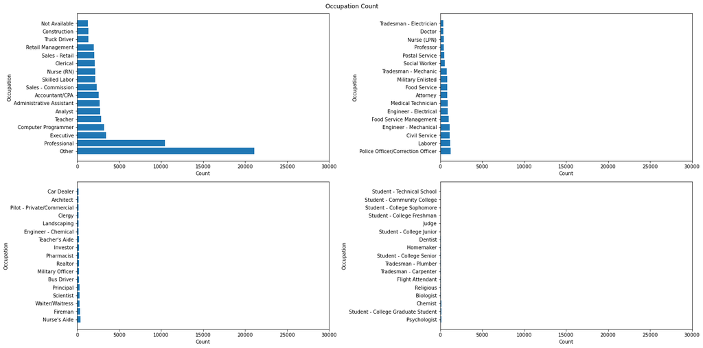

```python
# Use horizaontal bar chart
plt.figure(figsize=[20,10])

plt.subplot(2,2,1)
plt.barh(data=occupation1, y='occupation', width='count')
plt.xlim(0,30000)
plt.ylabel('Occupation')
plt.xlabel('Count')

plt.subplot(2,2,2)
plt.barh(data=occupation2, y='occupation', width='count')
plt.xlim(0,30000)
plt.ylabel('Occupation')
plt.xlabel('Count')

plt.subplot(2,2,3)
plt.barh(data=occupation3, y='occupation', width='count')
plt.xlim(0,30000)
plt.ylabel('Occupation')
plt.xlabel('Count')

plt.subplot(2,2,4)
plt.barh(data=occupation4, y='occupation', width='count')
plt.xlim(0,30000)
plt.ylabel('Occupation')
plt.xlabel('Count')

plt.suptitle('Occupation Count')
plt.tight_layout()
plt.show()
```

**Observation**

Occupation(Other) which was probably not in the option or not wanting to be listed by the borrower has the highest count, followed by Professional (Professional in what though?), Executive and Computer Programmer.

Occupations that least likely request for loans are Students(Technical School, Community College, College Freshman, College Sophomore, College Junior, College Senior and College Graduate. Though amongst these students category, the College graduate requests more for loans than the others),Judge and Dentist

**Question**

### 5) Do the Unemployed also request for loans?

**Visualization**

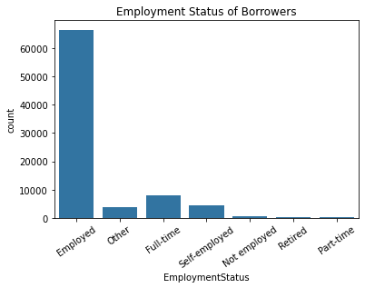

```python
#seaborn countplot
base_color=sns.color_palette()[0]
sns.countplot(data=prosper_df, x='EmploymentStatus', color=base_color)
plt.xticks(rotation=35)
plt.title('Employment Status of Borrowers')
plt.show()
```

**Observation**

As expected the employed category should be the ones that make more request for loans as they should have means to pay back without issues. Though there are a lot of other options I will classify Self-employed, Full-time, Part-time under the employed category. While the Retired should fall under the unemployed category(though they might be receiving pension)

## Bivariate

Checking the pairwise correlation between some features in the prosper_df

```python
# numeric columns
cols = ['LoanOriginalAmount','MonthlyLoanPayment','BorrowerRate','BorrowerAPR',
        'EstimatedEffectiveYield','EstimatedLoss','EstimatedReturn','LenderYield']
```

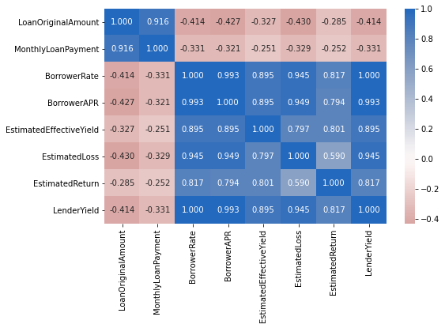

```python
# correlation plot
plt.figure(figsize = [8, 5])
sns.heatmap(prosper_df[cols].corr(), annot = True, fmt = '.3f',
           cmap = 'vlag_r', center = 0)
plt.show()
```

```python
# selecting 1000 random pictures
prosper_df_subset = prosper_df.sample(1000,replace=True)
```

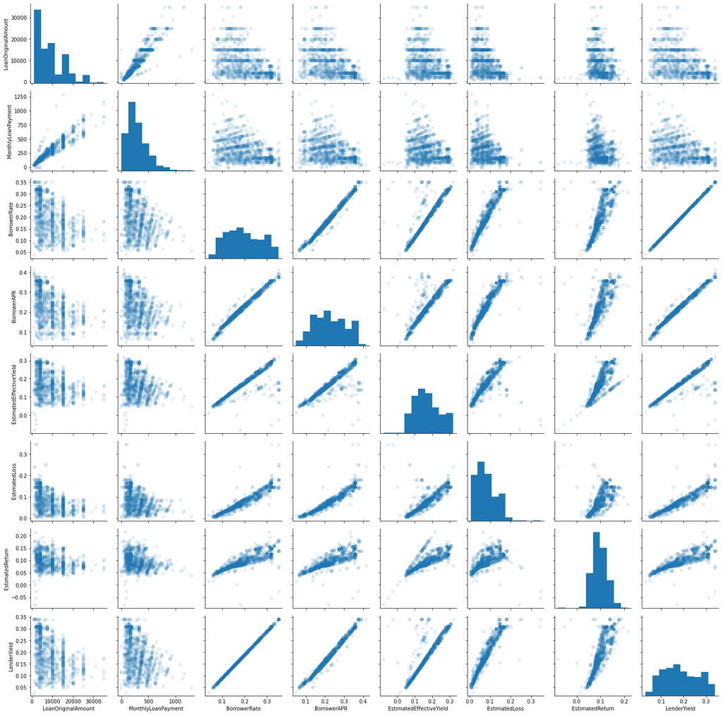

```python
g = sns.PairGrid(data=prosper_df_subset, vars=cols);
g.map_offdiag(plt.scatter, alpha=1/10)
g.map_diag(plt.hist);
```

**Observation**

Though this plot shows 1000 random data from the dataset

**Question**

### 6) Borrower APR Vs Annual Income

**Visualization**

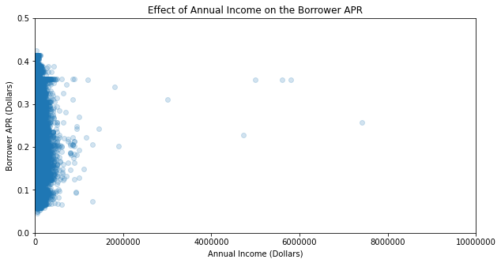

```python
# seaborn regplot
plt.figure(figsize=[10,5])
sns.regplot(data = prosper_df, x= 'AnnualIncome', y='BorrowerAPR',x_jitter=0.3, scatter_kws={'alpha':1/5}, fit_reg=False)
plt.ticklabel_format(style='plain',axis='x')
plt.xlim(0,10000000)
plt.ylim(0,0.5)
plt.xlabel('Annual Income (Dollars)')
plt.ylabel('Borrower APR (Dollars)')
plt.title('Effect of Annual Income on the Borrower APR');
```

**Observation**

The annual income does not have an exact effect on the APR(Annual Percentage Rate), a high annual income did not necessarily mean a high or low APR.

**Question**

### 7) Which state collects the highest amount of loan?

```python
new_state_loan_df = prosper_df.groupby('BorrowerState').LoanOriginalAmount.mean().reset_index('BorrowerState').sort_values(by='LoanOriginalAmount', ascending=False)
```

```python
new_state_loan_df.info()
```

```
<class 'pandas.core.frame.DataFrame'>
Int64Index: 48 entries, 7 to 38
Data columns (total 2 columns):
 #   Column              Non-Null Count  Dtype
---  ------              --------------  -----
 0   BorrowerState       48 non-null     object
 1   LoanOriginalAmount  48 non-null     float64
dtypes: float64(1), object(1)
memory usage: 1.1+ KB
```

```python
# split for easy plotting
new_state1 = new_state_loan_df.iloc[:12]
new_state2 = new_state_loan_df.iloc[12:24]
new_state3 = new_state_loan_df.iloc[24:36]
new_state4 = new_state_loan_df.iloc[36:]
```

**Visualization**

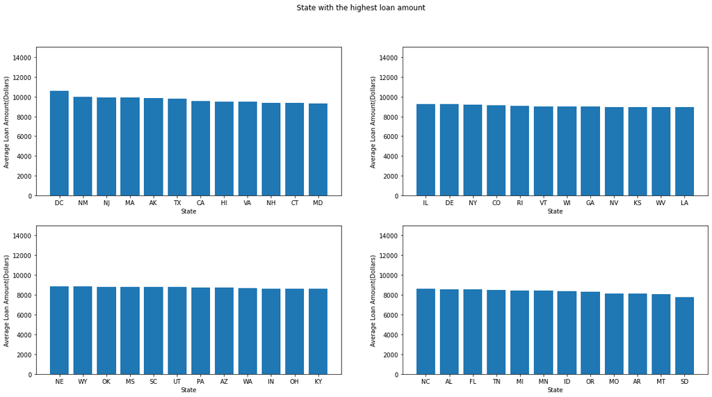

```python
# bar chart
plt.figure(figsize=[20,10])

plt.subplot(2,2,1)
plt.bar(data=new_state1, x='BorrowerState', height='LoanOriginalAmount')
plt.ylim(0,15000)
plt.xlabel('State')
plt.ylabel('Average Loan Amount(Dollars)')

plt.subplot(2,2,2)
plt.bar(data=new_state2,  x='BorrowerState', height='LoanOriginalAmount')
plt.ylim(0,15000)
plt.xlabel('State')
plt.ylabel('Average Loan Amount(Dollars)')

plt.subplot(2,2,3)
plt.bar(data=new_state3,  x='BorrowerState', height='LoanOriginalAmount')
plt.ylim(0,15000)
plt.xlabel('State')
plt.ylabel('Average Loan Amount(Dollars)')

plt.subplot(2,2,4)
plt.bar(data=new_state4,  x='BorrowerState', height='LoanOriginalAmount')
plt.ylim(0,15000)
plt.xlabel('State')
plt.ylabel('Average Loan Amount(Dollars)')

plt.suptitle('State with the highest loan amount')
plt.show()
```

**Observation**

Previously we saw that California was the state that requested for lots of loan in terms of number, meaning there was alot of loan request but in terms of amount Washighton DC actually request for higher loans as compared to California and other states folowed by New Mexico(NM).

Wonder what category such huge amount of loan fall into?

```python
# query for only DC state
dc = prosper_df.query('BorrowerState =="DC"')
dc['ListingCategory'].value_counts()
```

```
Debt consolidation           205
Other                         37
Business                      26
Home improvement              21
Auto                           7
Household Expenses             7
Engagement Ring Financing      5
Wedding Loans                  4
Large Purchases                3
Boat                           3
Medical/Dental                 2
Vacation                       1
Taxes                          1
Motorcycle                     1
Student use                    1
Baby & Adoption Loans          1
Cosmetic Procedures            0
Green Loans                    0
RV                             0
Personal loan                  0
Name: ListingCategory, dtype: int64
```

So we can see that most loan collected is for Debt Consolidation

```python
#query for only CA state
ca = prosper_df.query('BorrowerState =="CA"')
ca['ListingCategory'].value_counts()
```

```
Debt consolidation           6798
Other                        1107
Business                      698
Home improvement              693
Auto                          300
Household Expenses            207
Medical/Dental                188
Taxes                         132
Large Purchases               122
Wedding Loans                 112
Vacation                      106
Student use                    46
Motorcycle                     36
Engagement Ring Financing      28
Baby & Adoption Loans          22
Cosmetic Procedures            11
Green Loans                    11
RV                             11
Boat                            8
Personal loan                   0
Name: ListingCategory, dtype: int64
```

While for CA that has high amount of loan request, most request are for debt consolidation and a whole lot of others things unlike DC which is mainly Debt consolidation

**Question**

### 8) What affects the Interest rate?

**Visualization**

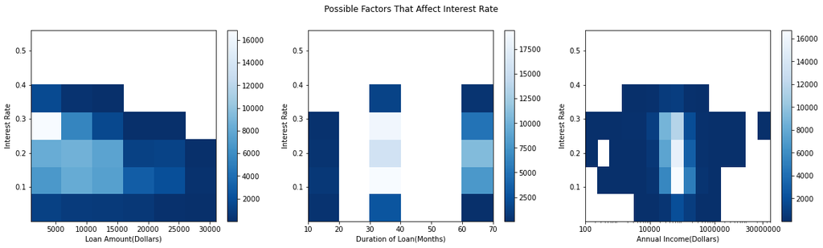

```python
#hist2d
plt.figure(figsize=[20,5])

plt.subplot(1,3,1)
bins_x = np.arange(1000, 35000+1000, 5000)
bins_y = np.arange(0.00001, 0.6, 0.08)
plt.hist2d(data=prosper_df, x='LoanOriginalAmount', y='BorrowerRate', cmin=0.5, cmap='Blues_r', bins=[bins_x, bins_y])
plt.xlabel('Loan Amount(Dollars)')
plt.ylabel('Interest Rate')
plt.colorbar();

plt.subplot(1,3,2)
bins_x = np.arange(10, 60+20, 10)
bins_y = np.arange(0.00001, 0.6, 0.08)
plt.hist2d(data=prosper_df, x='Term', y='BorrowerRate', cmin=0.2, cmap='Blues_r', bins=[bins_x, bins_y])
plt.xlabel('Duration of Loan(Months)')
plt.ylabel('Interest Rate')
plt.colorbar();

plt.subplot(1,3,3)
bins_x = 10**np.arange(2, 8, 0.38)
bins_y = np.arange(0.00001, 0.6, 0.08)
ticks = [100, 10000, 1000000, 30000000]
labels = ['{}'.format(v) for v in ticks]
plt.hist2d(data= prosper_df, x='AnnualIncome', y='BorrowerRate', cmin=0.5, cmap='Blues_r', bins=[bins_x,bins_y])
plt.xscale('log')
plt.xticks(ticks,labels)
plt.xlabel('Annual Income(Dollars)')
plt.ylabel('Interest Rate')
plt.colorbar();

plt.suptitle('Possible Factors That Affect Interest Rate');
```

**Observation**

For the relation of loan amount with interest rate, a high amount of loan does not necessarily mean a high interest rate. The heat map also shows that most loan amount is below 15000 with a rate around 0.1 and 0.2.

For the relation with the duration of loan(Term), the most common duration is that of 30-40 months with a rate between 0.1 and 0.3.

For the relation with the annual income, most income range falls between 10000 and 1000000. High income does not necessarily mean a high interest rate or a low interest rate also.

**Question**

### 9) Benefit of having a good Prosper Rating

**Visualization**

**Loan Amount**

```python
category = ['AA', 'A','B','C','D','E','HR']
rating_cat = pd.api.types.CategoricalDtype(ordered=True, categories=category)
prosper_df['ProsperRating (Alpha)'] = prosper_df['ProsperRating (Alpha)'].astype(rating_cat)
```

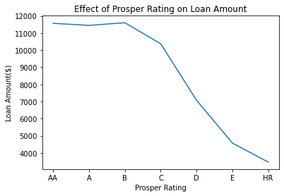

```python
#seaborn's lineplot
sns.lineplot(data=prosper_df, x='ProsperRating (Alpha)', y='LoanOriginalAmount', ci=None)
plt.xlabel('Prosper Rating')
plt.ylabel('Loan Amount($)')
plt.title('Effect of Prosper Rating on Loan Amount');
```

**Observation**

We could say those with good ratings "comfortably" request for high loan amount or have the benefit of requesting for high loan amount

**Visualization**

**Interest Rate**

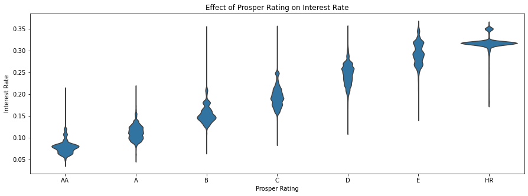

```python
# violinplot
base_color = sns.color_palette()[0]
plt.figure(figsize=[15,5])
sns.violinplot(data=prosper_df, x='ProsperRating (Alpha)', y='BorrowerRate', inner=None, color=base_color)
plt.xlabel('Prosper Rating')
plt.ylabel('Interest Rate')
plt.title('Effect of Prosper Rating on Interest Rate');
```

**Observation**

AA which is the best rating often receives lower interest rate as compared to HR(High Risk) rating which gets really high interest rate

**Visualization**

**Investors**

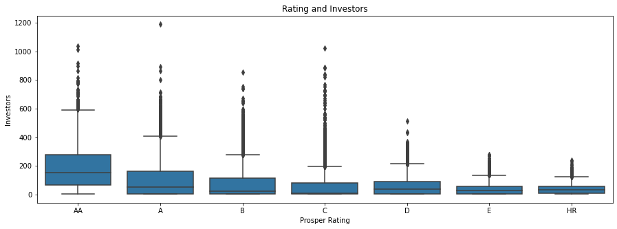

```python
# boxplot
plt.figure(figsize=[15,5])
base_color=sns.color_palette()[0]
sns.boxplot(data=prosper_df, x='ProsperRating (Alpha)', y='Investors', color=base_color)
plt.title('Rating and Investors')
plt.xlabel('Prosper Rating')
plt.ylabel('Investors');
```

**Observation**

Investors are readily available for borrowers who have a good prosper rating. No one wants to lose their money you know.

At this point we can say there are alot of benefits for having a good prosper rating.

**Question**

### What could affect these Prosper Rating?

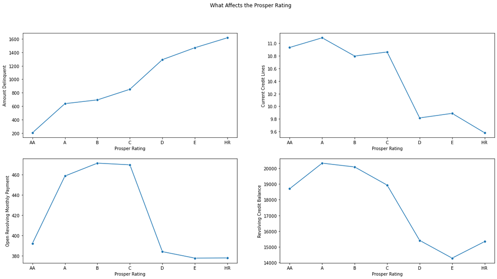

```python
# lineplot
plt.figure(figsize=[20,10])

plt.subplot(2,2,1)
sns.lineplot(data=prosper_df, x='ProsperRating (Alpha)', y='AmountDelinquent', marker="o", ci=None)
plt.xlabel('Prosper Rating')
plt.ylabel('Amount Delinquent')

plt.subplot(2,2,2)
sns.lineplot(data=prosper_df, x='ProsperRating (Alpha)', y='CurrentCreditLines', marker="o", ci=None)
plt.xlabel('Prosper Rating')
plt.ylabel('Current Credit Lines')


plt.subplot(2,2,3)
sns.lineplot(data=prosper_df, x='ProsperRating (Alpha)', y='OpenRevolvingMonthlyPayment', marker="o", ci=None)
plt.xlabel('Prosper Rating')
plt.ylabel('Open Revolving Monthly Payment')

plt.subplot(2,2,4)
sns.lineplot(data=prosper_df, x='ProsperRating (Alpha)', y='RevolvingCreditBalance', marker="o", ci=None)
plt.xlabel('Prosper Rating')
plt.ylabel('Revolving Credit Balance')

plt.suptitle('What Affects the Prosper Rating');
```

**Question**

What of the annual income and debt to income ratio?

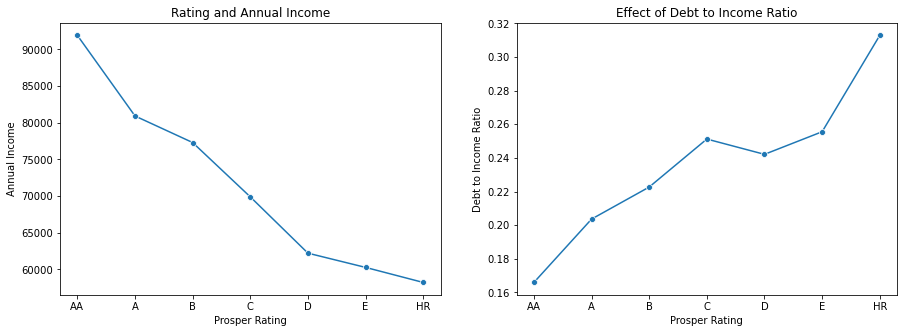

```python
plt.figure(figsize=[15,5])
plt.subplot(1,2,1)
sns.lineplot(data=prosper_df, x='ProsperRating (Alpha)', y='AnnualIncome', marker='o', ci=None)
plt.xlabel('Prosper Rating')
plt.ylabel('Annual Income')
plt.title('Rating and Annual Income')

plt.subplot(1,2,2)
sns.lineplot(data=prosper_df, x='ProsperRating (Alpha)', y='DebtToIncomeRatio', marker="o", ci=None)
plt.xlabel('Prosper Rating')
plt.ylabel('Debt to Income Ratio');
plt.title('Effect of Debt to Income Ratio');
```

**Observation**

- Amount delinquent, poor ratings have high amount of delinquents.
- Current credit lines, good ratings have high number of current credit line
- Open Revolving Monthly Payment, good ratings are have higher though AA rating is way lower than A, B and C
- Revolving Credit Balance, good ratings have high amount

**Being a home owner**

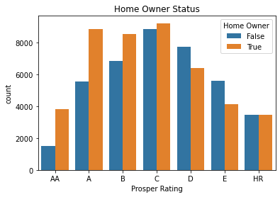

```python
sns.countplot(data=prosper_df, x='ProsperRating (Alpha)', hue='IsBorrowerHomeowner')
plt.xlabel('Prosper Rating')
plt.legend(title='Home Owner')
plt.title('Home Owner Status');
```

Those with good rating have a high amount of those who are home owners

**Question**

Looking at some states and their rating.

```python
# selecting states
state_df =['DC', 'NM', 'NJ', 'CA','NY', 'TX', 'SD', 'MT', 'AR', 'WY','AK', 'VT']

prosper_state_df = prosper_df[prosper_df['BorrowerState'].isin(state_df)]
```

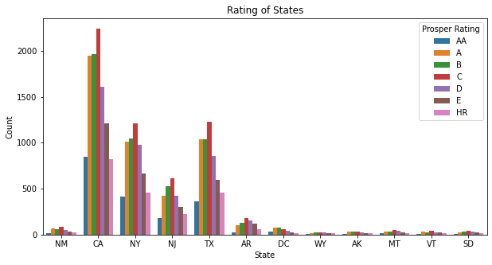

```python
# use seaborn countplot
plt.figure(figsize=[10,5])
sns.countplot(data=prosper_state_df, x='BorrowerState', hue='ProsperRating (Alpha)')
plt.xlabel('State')
plt.ylabel('Count')
plt.legend(title='Prosper Rating')
plt.title('Rating of States');
```

```python
prosper_df['ProsperRating (Alpha)'].value_counts()
```

```
C     18096
B     15368
A     14390
D     14170
E      9716
HR     6917
AA     5325
Name: ProsperRating (Alpha), dtype: int64
```

**Observation**

For the selected states the most common rating is C followed by B, A, D, E, HR and AA

**Question**

**Visualization**

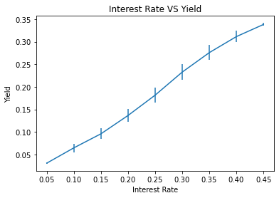

```python
# errorbar
bin_edges = np.arange(0.0001, 0.5+0.3, 0.05)
bin_centers = bin_edges[:-1] + 0.05
displ_binned = pd.cut(prosper_df['BorrowerAPR'], bin_edges, include_lowest = True)

yield_mean = prosper_df['LenderYield'].groupby(displ_binned).mean()
yield_std = prosper_df['LenderYield'].groupby(displ_binned).std()

plt.errorbar(x=bin_centers, y=yield_mean, yerr=yield_std)

plt.xlabel('Interest Rate')
plt.ylabel('Yield')

plt.title('Interest Rate VS Yield');
```

**Observation**

There is a linear relationship between the interest rate and the lender yield.

**Question**

### 11) With respect to the loan amount, how often is the loan cleared?

**Visualization**

```python
prosper_df['LoanStatus'].value_counts()
```

```
Current                   55730
Completed                 19651
Chargedoff                 5336
Defaulted                  1005
Past Due (1-15 days)        800
Past Due (31-60 days)       361
Past Due (61-90 days)       311
Past Due (91-120 days)      304
Past Due (16-30 days)       265
FinalPaymentInProgress      203
Past Due (>120 days)         16
Name: LoanStatus, dtype: int64
```

```python
status = ['Current', 'Completed','FinalPaymentInProgress','Past Due (1-15 days)',
          'Past Due (16-30 days)','Past Due (31-60 days)','Past Due (61-90 days)',
          'Past Due (91-120 days)','Past Due (>120 days)','Chargedoff','Defaulted']
status_cat = pd.api.types.CategoricalDtype(ordered=True, categories=status)
prosper_df['LoanStatus'] = prosper_df['LoanStatus'].astype(status_cat)
```

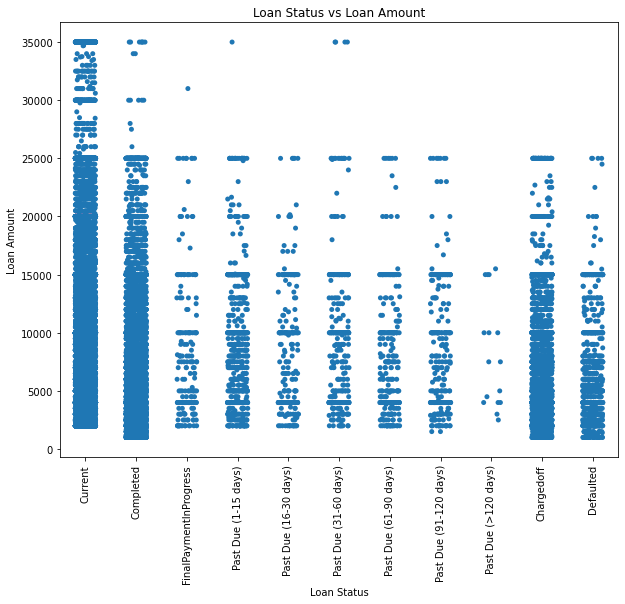

```python
# Use stripplot
plt.figure(figsize=[10,8])
color = sns.color_palette()[0]
sns.stripplot(data=prosper_df, x='LoanStatus', y='LoanOriginalAmount',jitter=0.2, color=color, dodge=True)
plt.xticks(rotation=90)
plt.xlabel('Loan Status')
plt.ylabel('Loan Amount')
plt.title('Loan Status vs Loan Amount');
```

**Observation**

Most loans in this dataset have loan status of Current or Completed. It also does not show that higher loan amount takes time to be paid, in fact some of the highest amount are in the Current or Completed status.

Can we check this out with the prosper rating?

### Multivariate

My main aim is to see how Prosper rating affects some loan features in this dataset.

**Visualization**

```python
# select random 2000 smaples from dataset
prosper_df_subset = prosper_df.sample(2000,replace=True)
```

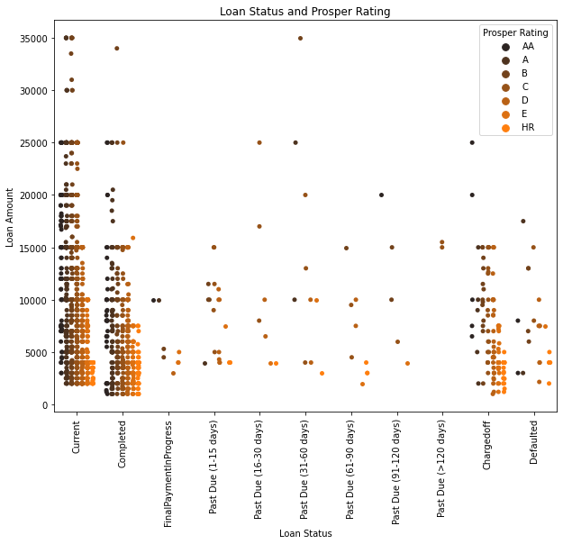

```python
# use stripplot
plt.figure(figsize=[10,8])
color = sns.color_palette()[1]
sns.stripplot(data=prosper_df_subset, x='LoanStatus', y='LoanOriginalAmount', hue='ProsperRating (Alpha)',color=color, dodge=True)
plt.xticks(rotation=90)
plt.xlabel('Loan Status')
plt.ylabel('Loan Amount')
plt.title('Loan Status and Prosper Rating')
plt.legend(title='Prosper Rating');
```

**Obseravtion**

First of, this plot shows those with poor rating do not really borrow very high amount and those with really good ratings (AA,A,B) rarely appear in other loan status asides Current and Completed.

**Question**

### 12) Interest Rate, Loan Amount and Monthly Loan Payment

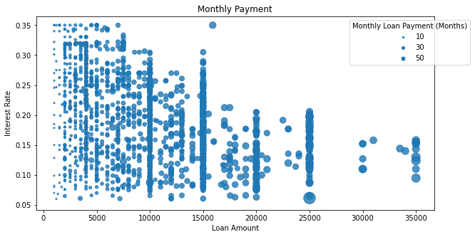

```python
# use seaborn regplot
plt.figure(figsize=[10,5])

sns.regplot(data = prosper_df_subset, x='LoanOriginalAmount', y='BorrowerRate',x_jitter = 0.9, fit_reg=False,
           scatter_kws= {'s' : prosper_df_subset['MonthlyLoanPayment']/8})
sizes = [10,30,50]
base_color = sns.color_palette()[0]
legend_obj = []
for s in sizes:
    legend_obj.append(plt.scatter([],[], s=s/2, color = base_color))
ax = plt.gca()
plt.legend(legend_obj,sizes, title = 'Monthly Loan Payment (Months)', bbox_to_anchor=(1.1,1.0), bbox_transform=ax.transAxes)
plt.title('Monthly Payment')
plt.xlabel('Loan Amount')
plt.ylabel('Interest Rate');
```

**Observation**

Monthly payment of loan is larger for high amount of loans and it does look like there is lower interest rate for higher monthly payment.

**Question**

### 13) Viewing the Interest rate on loan duration with respect to loan amount

**Visualization**

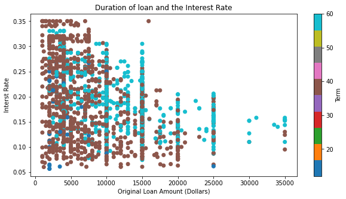

```python
# with scatterplot
plt.figure(figsize=[10,5])
plt.scatter(data=prosper_df_subset, x='LoanOriginalAmount', c='Term', y='BorrowerRate', cmap='tab10')
plt.colorbar(label='Term')
plt.xlabel('Original Loan Amount (Dollars)')
plt.ylabel('Interst Rate')
plt.title('Duration of loan and the Interest Rate');
```

**Observation**

Most loans are spread across 36 months but higher amount of loans are mostly spread across longer months(60 months) but with lower interest rate.

Will investors be interested in such deals?

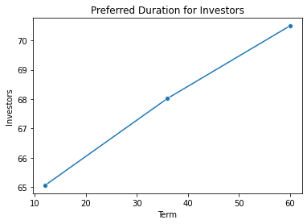

```python
# lineplot
sns.lineplot(data=prosper_df, x='Term', y='Investors', ci=None, marker="o")
plt.title('Preferred Duration for Investors');
```

**Observation**

The number of investors increase as the term of loan increases.

**Question**

### 14) Estimated Effective Yield, Estimated Loss and Estimated Return

**Visualization**

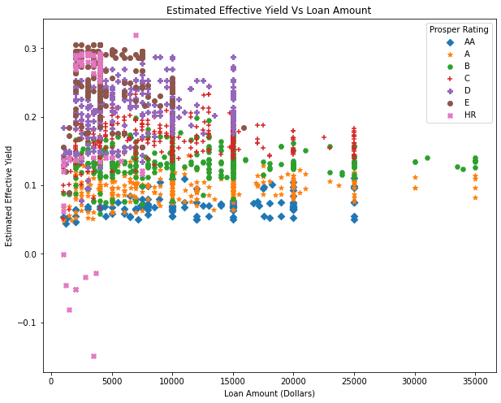

```python
plt.figure(figsize=[10,8])
#speciify markers for each rating
rate_markers = [['AA', 'D'],
               ['A', '*'],
               ['B', 'H'],
               ['C', '+'],
               ['D', 'P'],
               ['E', 'o'],
               ['HR', 'X']]

for rate, marker in rate_markers:
    rate_estimate_data = prosper_df_subset.loc[prosper_df_subset['ProsperRating (Alpha)'] == rate]
    plt.scatter(data = rate_estimate_data, x = 'LoanOriginalAmount', y = 'EstimatedEffectiveYield', marker = marker)

plt.xlabel('Loan Amount (Dollars)')
plt.ylabel('Estimated Effective Yield')
plt.title('Estimated Effective Yield Vs Loan Amount')
plt.legend(['AA','A','B','C','D','E','HR'], title='Prosper Rating');
```

**Observation**

Most good ratings have lower estimated effective yield as compared to poor ratings.

**Visualization**

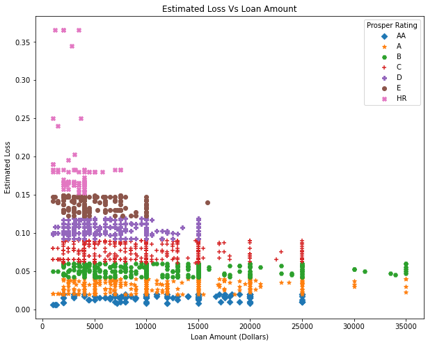

```python
plt.figure(figsize=[10,8])

rate_markers = [['AA', 'D'],
               ['A', '*'],
               ['B', 'H'],
               ['C', '+'],
               ['D', 'P'],
               ['E', 'o'],
               ['HR', 'X']]

for rate, marker in rate_markers:
    rate_estimate_data = prosper_df_subset.loc[prosper_df_subset['ProsperRating (Alpha)'] == rate]
    plt.scatter(data = rate_estimate_data, x = 'LoanOriginalAmount', y = 'EstimatedLoss', marker = marker)

plt.xlabel('Loan Amount (Dollars)')
plt.ylabel('Estimated Loss')
plt.title('Estimated Loss Vs Loan Amount')
plt.legend(['AA','A','B','C','D','E','HR'], title='Prosper Rating');
```

Borrower's with good rating have lower estimated loss as compared to those with poor rating.

**Visualization**

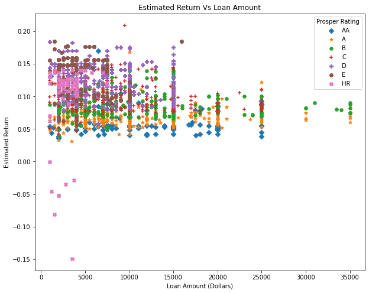

```python
plt.figure(figsize=[10,8])

rate_markers = [['AA', 'D'],
               ['A', '*'],
               ['B', 'H'],
               ['C', '+'],
               ['D', 'P'],
               ['E', 'o'],
               ['HR', 'X']]

for rate, marker in rate_markers:
    rate_estimate_data = prosper_df_subset.loc[prosper_df_subset['ProsperRating (Alpha)'] == rate]
    plt.scatter(data = rate_estimate_data, x = 'LoanOriginalAmount', y = 'EstimatedReturn', marker = marker)

plt.xlabel('Loan Amount (Dollars)')
plt.ylabel('Estimated Return')
plt.title('Estimated Return Vs Loan Amount')
plt.legend(['AA','A','B','C','D','E','HR'], title='Prosper Rating');
```

**Observation**

Good prosper ratings have low estimated return as compared to prosper rating.

From all the plots for the estimates, it can slso be observed that most high amount of loans are for those with good ratings (AA,A,B and C)

**Question**

### 15) Comparing some states and Income Range

```python
prosper_df['IncomeRange'].value_counts()
```

```
$50,000-74,999    25326
$25,000-49,999    23923
$100,000+         15056
$75,000-99,999    14362
$1-24,999          4621
Not employed        649
$0                   45
Name: IncomeRange, dtype: int64
```

```python
# make range categorical data
category = ['$100,000+','$75,000-99,999','$50,000-74,999','$25,000-49,999','$1-24,999','Not employed']
income_cat = pd.api.types.CategoricalDtype(ordered=True, categories=category)

prosper_df['IncomeRange'] = prosper_df['IncomeRange'].astype(income_cat)
```

```python
# select only DC, CA, NJ, MA and TX
state_list =['DC', 'NM', 'NJ', 'CA','NY', 'TX']

prosper_state = prosper_df[prosper_df['BorrowerState'].isin(state_list)]
```

**Visualization**

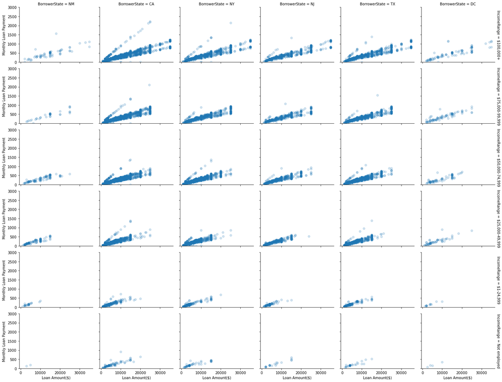

```python
# facetgrid
h = sns.FacetGrid(data = prosper_state, col = 'BorrowerState', row='IncomeRange', height = 2.5,
                margin_titles = True)
h.map(plt.scatter, 'LoanOriginalAmount', 'MonthlyLoanPayment', alpha=1/5)
h.fig.set_size_inches(20,15)
h.set_axis_labels("Loan Amount($)", "Monthly Loan Payment")
plt.ylim(0,3000);
```

**Observation**

- The monthly loan payment increases with an increase in the loan original amount
- There is a large amount of borrowers who get income of 100,000+ in California(CA) followed byTexas(TX), New York(NY), New Jersey(NJ), Washinghton DC and finally New Mexico(NM)
- Not so many unemployed people in NM followed by DC then NJ,TX,NY and finally CA
- People with low income range do not request for high loan amount

Then least 3 states that request for loans the least(WY, AK, VT) and least 3 states that request for low amount of loan(SD, MT,AR)

```python
state_list2 =['SD', 'MT', 'AR', 'WY','AK', 'VT']

prosper_state2 = prosper_df[prosper_df['BorrowerState'].isin(state_list2)]
```

**Visualization**

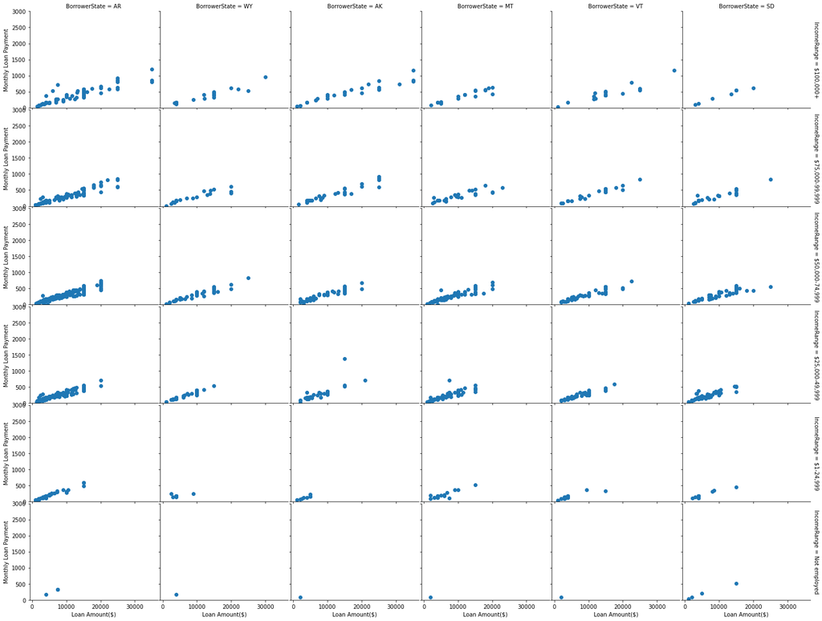

```python
l = sns.FacetGrid(data = prosper_state2, col = 'BorrowerState', row='IncomeRange', height = 10,
                margin_titles = True)
l.map(plt.scatter, 'LoanOriginalAmount', 'MonthlyLoanPayment')
l.fig.set_size_inches(20,15)
l.set_axis_labels("Loan Amount($)", "Monthly Loan Payment")
plt.ylim(0,3000);
```

**Observation**

- Arkansas has alot of people who earn $100,00+ followed by Alaska
- South Dakota has the more unemployed people followed by Arkansas
- People with low income range rarely request for large loan amount

## Conclusion

- Most loans are requested for Debt consolidation which is combining several loans or liabilities into one by taking out a new loan to pay off the debts
- California is the state with the most requests for loans but Washington DC request for way higher loans in terms of amount. From the investigation both states commonly request for these loans for Debt Consolidation but California also has alot of other reasons for loan request like businees, home improvement, auto etc. unlike DC.
- It also shows that it is mostly those who are employed that request for loans and the occupation that request for loan most is Professional asides Others which does not exactly state the occupation in particular.
- Considering the Income range, it shows that those with low income range rarely request for high loans. Studying some specific state it is observed that California has alot of people whose income range is around $100,000+
- Most loan of high amount are spread over longer period of months but with lower interest rate but this does not affect the number of investors as investors increase with loan term increase. The analysis also shows the interest rate is proportional to lender yield so low interest rate gives low lender yield and vice versa.
- Having looked at alot of features, the analysis shows that the Prosper rating of the borrower affects quite a number of things and it is of great benefit if the borrower has a good Prosper rating. A good Prosper rating allows for the borrower to have a lower interest rate and investors are always quite ready to put their money in loans whose borrower has a good rating. Good rating also has a low estimated loss, low estimated effective yield and low estimated return as compared to poor ratings. The low estimated return and low estimated effective yield of a good rating would be because those with good rating have lower interest rate than those with poor rating, from the PairGrid an increase in interest rate also means an increase in these estimates. So, even though good ratings do not have high estimated return it is cerain the investor gets his money back unlike HR(High Risk) rating which has a high estimated loss as the assurance of getting the money back is low but because of its high interest rate, it automatically gets a high estimated return and estimated effective yield.
- Investigating some specific states, it shows that C is a very common rating followed by B, A, D, E, HR and AA
- It was of concern to know to an extent what gives a good prosper rating and from the analysis it shows good ratings have low amount delinquent, high current credit line, high amount of revolving credit balance, low debt to income ratio and are most times home owners.
- Analysis also shows that monthly payment increases with loan amount and the interest rate for smaal amount of loan is higher as compared to larger loans
- Most loan fall in the status of Current and Completed, it also shows that the status of a loan does not necessarily depend on the amount and rarely does borrowers with good rating fall into other loan status category asides Current and Completed. Also, most borrowers with good rating borrow high amount of loan as compared to those with poor rating.

### Limitations

- Occupation not specified. Others does not exactly say which occupation
- Listing Category not specified. Others does not exactly say reason for loan